# Teto remuneratório é insignificante diante de superindenizações no sistema de Justiça da Paraíba

[output not shown]

Dados coletados e padronizados pelo DadosJusBr – um projeto em parceria entre Universidade Federal de Campina Grande, o Instituto Federal de Alagoas e a Transparência Brasil – revelam que de 2018 a 2020 os cofres públicos pagaram em média R$ 44.815 ao mês para seus procuradores estaduais (MP-PB), R$ 38.299 para magistrados estaduais (TJ-PB) e R$ 43.871 para magistrados da Justiça do Trabalho no estado (TRT-13). Magistrados do TRE-PB, que são cedidos de outras cortes, recebem pagamentos por sessões que lhe renderam em média R$ 3.387 mensais adicionais.

Os gastos com os demais servidores da corte são significativamente mais baixos: enquanto os órgãos estaduais pagam em média R$ 7.359 (MP-PB) e R$ 8.274 (TJ-PB), as cortes cujo orçamento vem da União são bastante superiores: R$ 15.632 (TRE-PB) e R$ 19.142 (TRT-13). De fato, é comum que a União pague mais por seus servidores que estados e municípios, o que torna ainda mais impressionantes os elevados gastos que os cofres estaduais têm com os procuradores estaduais.

Como forma de tentar evitar abusos nos recebimentos das elites do serviço público, a Constituição impõe o teto remuneratório com a finalidade de estabelecer limites a recebimentos de servidores públicos, impedindo que os interesses econômicos pessoais se sobreponham ao interesse público. A despeito dos princípios de equidade e economicidade, o sistema de Justiça foi capaz de criar mecanismos legais para burlar esse teto oferecendo a magistrados grandes porções do orçamento público.

Além do subsídio mensal, que é uma espécie de salário base, os servidores recebem diversas gratificações, referentes por exemplo a tempo de serviço ou adicionais por exercício de algum cargo especial ou atividade extra. A soma do salário base mais esses benefícios não podem ultrapassar o teto remuneratório de R$ 39,2 mil. Caso supere, há um abatimento para que o servidor receba dentro do estabelecido constitucionalmente. Parte desses benefícios são montantes que não são abatidos do teto, como férias, décimo terceiro.

Mas além do salário e dos benefícios, há ainda outra categoria de recebimentos que se conveniou chamar de “indenizações”[^1]. Pela acepção da palavra, indenizações são ressarcimentos, como diárias, por exemplo, para participar de eventos externos. Sobre esses gastos não incidem o teto e faria sentido, se se tratasse apenas de reembolso por gastos com exercício da função – ainda que possam ser questionáveis os montantes reservados para isso.

No entanto, o sistema de Justiça resolveu “indenizar” generosamente os membros da magistratura e do Ministério Público por alguns custos que a maioria das pessoas têm de arcar com seus salários: custos de creches, alimentação, moradia, saúde, mudança, reclusão, funeral, entre outros.

Sobre esses recebimentos não apenas não incide o teto, como tão pouco incide imposto de renda, ou seja, trata-se de rendimentos líquidos. Como resultado, o desconto do teto é irrisório diante das saídas legais que tornam onerosos os pagamentos da folha de pessoal do sistema de Justiça. É o poder da elite do serviço público de capturar recursos estatais a despeito do objetivo de limitar tal captura com o teto constitucional. Reflexo disso são as indenizações retroativas de até seis dígitos que eventualmente aparecem nas folhas de pagamento por algum direito recalculado.

#### Gráfico: Quantidades de pagamentos acima de R$50.000 realizados entre 2018 e 2020

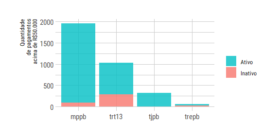

### Gastos com pessoal

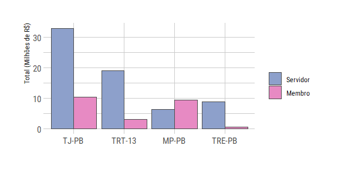

O TJ-PB gasta desde 2018 em média **R$43** milhões por mês com pagamentos para cerca de **4.258** membros e servidores. O TRT-13 gasta em torno de **R$31** milhões mensais com cerca de **1.560** membros e servidores, mas apresenta picos significativos em novembro e dezembro em função de benefícios. O MP-PB gasta em torno de **R$20** milhões com seus aproximados **1.295** funcionários e o TRE, mais de **R$11** milhões com aproximadamente de **830** funcionários.

#### Gráfico: Quantidade de servidores - média anual (2018 - 2020)

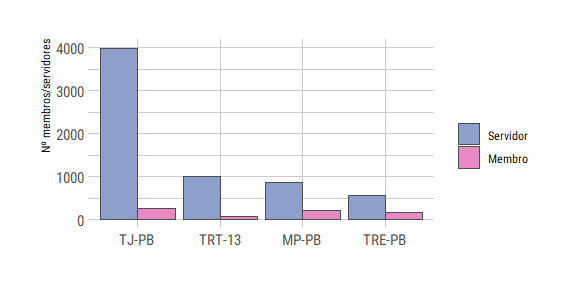

O gráfico a seguir mostra os montantes gastos mensalmente com pessoal por órgão desde 2018. Nas barras, o que está em verde é referente a servidores ativos, enquanto em vermelho, inativos. Como é possível observar, o TJ-PB, maior em volume de gastos, é o único que não informa o quanto gasta com seus funcionários inativos e pensionistas. Os meses que não apresentam dados são devido a problemas na prestação de contas dos respectivos órgãos.

#### Gráfico: Total gasto por mês com pessoal* por órgão do sistema de Justiça da Paraíba (2018-2020)

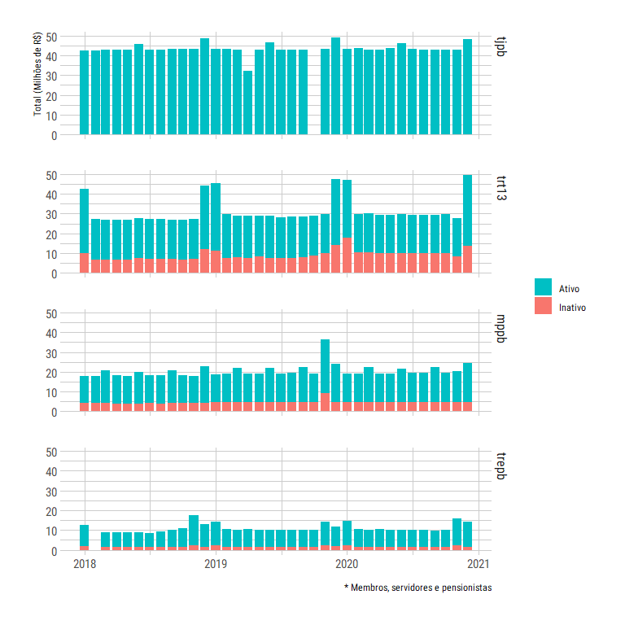

### Salários, benefícios, diárias e indenizações dos membros do sistema de justiça da Paraíba

Os órgãos do sistema de Justiça costumam distinguir a elite dos seus servidores públicos chamando-os de “membros”, que são basicamente magistrados, procuradores e promotores. As diferenças dos recebimentos entre membros e o restante dos servidores públicos é substantiva.

#### Gráfico: gasto médio mensal por membros e servidores (2018 - 2020)

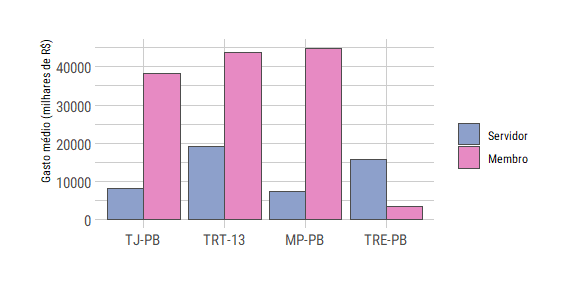

Em média, os pagamentos registrados a membros são 3,7 vezes maiores que os recebidos por demais servidores. Além dos salários de magistrados e procuradores serem mais elevados, a longa lista de benefícios e “indenizações” reforçam a desigualdade na distribuição dos recursos públicos. Parte dos recebimentos são exclusivos a membros, como auxílio-moradia e “compensação ao empregado por algum direito adquirido”. Em outros casos, o montante destinado a eles é maior para as mesmas rubricas, como “pagamento ao empregado por alguma vantagem e direito do servidor público”.

Analisando a média mensal de recebimentos de membros, vê-se que os ganhos que fundamentalmente variam entre órgãos (com exceção do TRE-PB) não são salários (em torno de **R$32** mil mensais por membro), mas sim os benefícios e “indenizações” adicionais, que garantem em média entre **R$4 mil** e **R$9,2 mil** todo mês a depender do órgão.

Como é possível perceber pelo gráfico a seguir, o MP-PB usa consideravelmente mais que o TRT-13 e o TJ-PB das “indenizações” para aumentar seus rendimentos. As diárias, que não são baratas, não estão contabilizadas aqui e foram analisadas separadamente em seção à frente. A Justiça Eleitoral que não tem corpo próprio de magistratura, mas conta com juízes de outros Tribunais, apresenta apenas gastos com benefícios. É o único caso em que gastos com demais servidores superam os de membros.

#### Gráfico: Recebimento médio de um membro

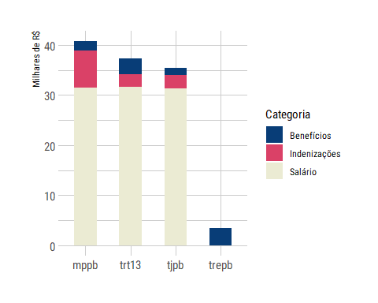

#### Gráfico: 40 maiores recebimentos de cada órgão do sistema de Justiça da Paraíba (somente membros ativos e sem diárias)

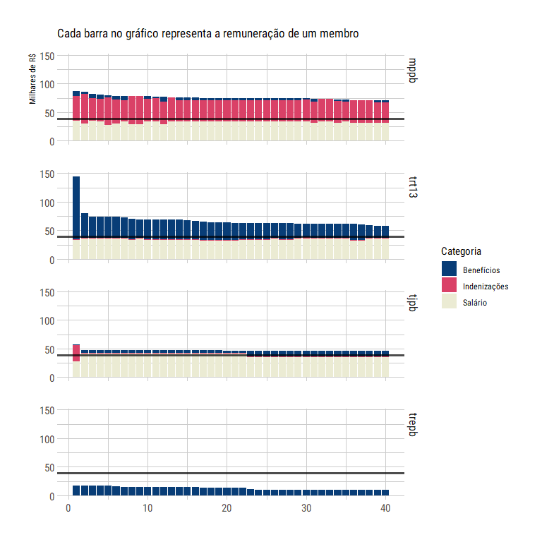

A linha que corta cada um dos quatro gráficos anteriores representa o limite do teto remuneratório. Como é possível observar, em geral os salários não batem o teto, mas é devido aos benefícios e “indenizações” que os membros conseguem seus altos recebimentos. Conclui-se, portanto, que o teto remuneratório é insignificante para controlar ganhos exorbitantes do alto escalão do judiciário que, quando ultrapassam o teto remuneratório, produzem apenas descontos marginais.

No TJ-PB o teto produziu descontos pequenos de no máximo R$ 1.488 diante dos R$ 45.216 recebidos - em média - pelos seus membros mais onerosos. Nos maiores pagamentos feitos pelo TRT-13 e pelo MP-PB, a regra não produziu qualquer desconto de teto remuneratório sobre recebimentos médios de R$ 67.399 e R$ 75.564, respectivamente.

#### Gráfico: Recebimento médio de um membro por categoria e ano

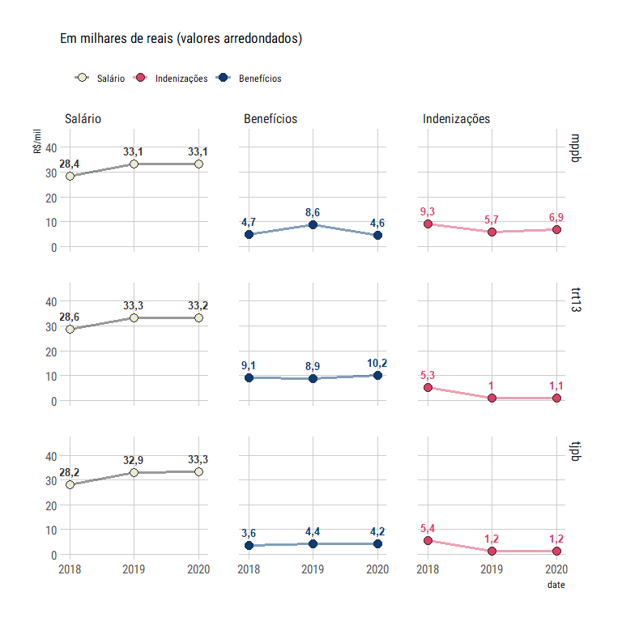

No gráfico a seguir analisamos a dispersão dos pagamentos totais (salários, indenizações e benefícios, exceto diárias) feitos a todos os membros ativos[^3] nos quatro órgãos de Justiça. Cada ponto no gráfico representa o maior pagamento recebido por algum membro e a reta vertical mais escura representa o limite estabelecido pelo teto remuneratório.

#### Gráfico: Maiores recebimentos em um mês - salário, indenização e benefícios (exceto diárias)

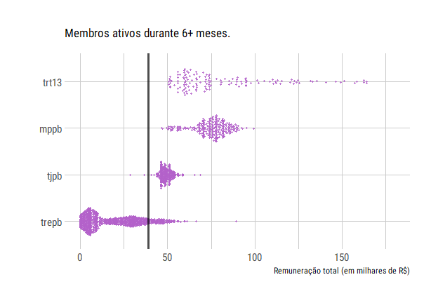

### Indenizações

As indenizações pagas (exceto diárias) no MPPB foram a principal forma de aumentar os ganhos dos membros para além do teto constitucional. Quase todos os membros do MPPB receberam pagamentos de indenizações que superam os R$ 15 mil. O gráfico a seguir apresenta o maior dos pagamentos de indenizações feitos para cada membro ativo dos tribunais e MP por 6 meses ou mais.

#### Gráfico: Maiores indenizações recebida em um mês

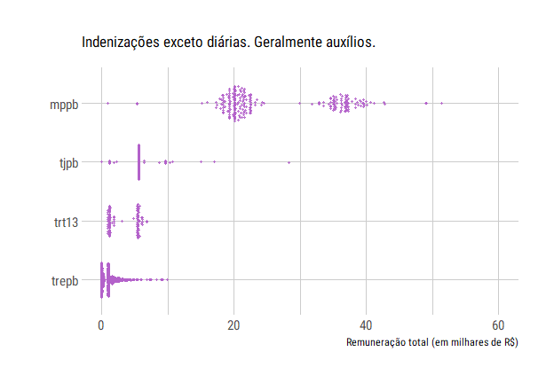

### Diárias

Somente o TJ-PB e o TRT-13 possuem dados específicos sobre diárias pagas para membros e servidores e que no período de 2018 e 2020 o montante de pagamentos chegou a R$ 3,7 milhões e R$ 2,5 milhões de reais para os tribunais, respectivamente. O gráfico a seguir apresenta a evolução desses valores no período, refletindo em 2020 a adesão de membros e servidores ao home office como medida de restrição adotada em função da pandemia do novo Coronavírus.

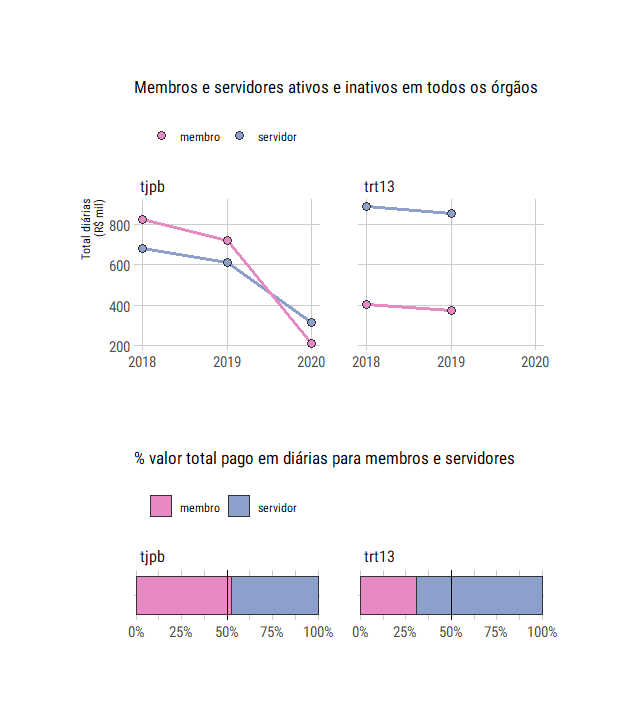

Na comparação entre os valores de diárias pagas a membros e servidores os gastos com diárias é substancialmente maior para os membros, a despeito do fato de representarem uma parcela bem menor da quantidade total de pagamentos. O TJ-PB realizou pagamentos a 626 pessoas inativas e ativas na folha de pagamento da Corte. Desses, somente 100 (16%) eram magistrados, que embolsaram cerca de 52% do valor total das diárias pagas pelo Tribunal. Já o TRT-13 realizou pagamentos a 294 pessoas inativas e ativas, sendo 47 (16%) delas magistrados, cujo pagamento de diárias representam 31% do total gasto pelo Tribunal.

#### Gráfico: Valor médio recebido por membros e servidores

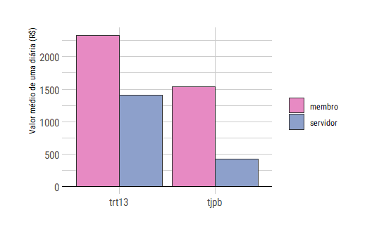

### Benefícios e gratificações

#### Gráfico: Maior benefício recebido em um mês

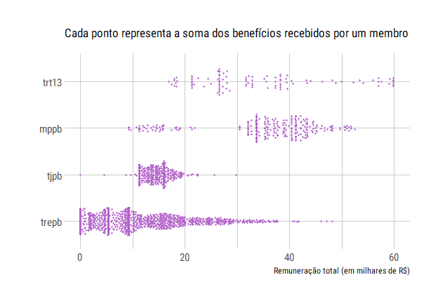

#### Tabela: Maiores pagamentos de benefício por tipo e órgão

|  | MPPB | TJPB | TREPB | TRT13 |
| --- | --- | --- | --- | --- |
| funds_trust_position | 3.831 | 0 | 17.022 | 0 |
| funds_eventual_benefits | 42.539 | 29.697 | 67.834 | 125.950 |
| funds_personal_benefits | 12.476 | 4.965 | 24.561 | 94.566 |
| funds_origin_pos | 0 | 0 | 27.370 | 0 |
| funds_gratification | 0 | 5.319 | 0 | 42.349 |

### Notas técnicas

Notas técnicas

Membros: em geral são magistrados, procuradores e promotores. É uma classificação mais ampla que abrange todo o tipo agente público que “representa” o Poder Judiciário ou o Ministério Público. Os dados fornecidos pelo TRE, no entanto, são problemáticos: a classificação de funções inclui cargos específicos como diferentes tipos de juízes (“juiz convocado” e “juiz eleitoral”, por exemplo) e categorias que não correspondem a cargos, mas à situação (ex: “inativo”, “removido”, “lotação provisória” e “sem vínculo”). Classificamos como membros os que poderíamos afirmar que o são efetivamente, o restante ficou no grupo de demais servidores.

Servidores: um servidor público é um funcionário da administração pública que possui um vínculo de trabalho com órgãos que fazem parte do Estado.

Pensionistas: São beneficiários de pensão por morte de algum funcionário do poder público.

Salário: salário básico que compõe a remuneração de um membro, limitado pelo teto de remuneração do funcionalismo público de R$39,2 mil.

Indenizações: são pagamentos referentes à auxílio alimentação, férias, transporte, auxílio creche, auxílio saúde, auxílio natalidade, auxílio moradia, ajuda de custo, licença compensatória e outras compensações por direito adquirido.

[^1]: Resoluções [13/2006](https://atos.cnj.jus.br/atos/detalhar/177) e [14/2006](https://atos.cnj.jus.br/atos/detalhar/178) do Conselho Nacional de Justiça e [9/2006](https://www.cnmp.mp.br/portal/images/Resolucoes/Resolu%C3%A7%C3%A3o-0091.pdf) e [10/2006](https://www.cnmp.mp.br/portal/images/Resolucoes/Resolu%C3%A7%C3%A3o-0101.pdf) do Conselho Nacional do Ministério Público.
[^2]: De acordo com o IBGE https://sidra.ibge.gov.br/tabela/5938#resultado
[^3]: Foram filtrados aqueles que aparecem ativos por pelo menos seis meses.